# package:assertr

# Load library

```r
config <- yaml::read_yaml("config.yaml")
for (p in config$LIBS$CRAN) {
  if (!require(p, character.only = TRUE)) {
    install.packages(p)
  }
  require(p, character.only = TRUE)
}
```

# assertr

アサートを行うパッケージである. `stopifnot`と異なり評価が成功する場合には, invisibleで引数を返すため, パイプの中で連続した処理が可能となる.

データ分析のおいてはデータが適当であるのかについては常に注意が必要である. 特にデータを書き出しを伴う時には余計な変更が伴うことがある. 注意が必要.

下記は参行文献である.

- [アサートを使って堅牢なデータ設計をしよう](https://uribo.hatenablog.com/entry/2016/03/19/110000)
- [viggnet](https://cran.r-project.org/web/packages/assertr/vignettes/assertr.html)

# Example

## Example

### assert

```r
our_data <- mtcars
our_data$mpg[5] <- our_data$mpg[5] * -1
our_data[4:6,]
```

|  | mpg | cyl | disp | hp | drat | wt | qsec | vs | am | gear | carb |
| --- | --- | --- | --- | --- | --- | --- | --- | --- | --- | --- | --- |
| Hornet 4 Drive | 21.4 | 6 | 258 | 110 | 3.08 | 3.215 | 19.44 | 1 | 0 | 3 | 1 |
| Hornet Sportabout | -18.7 | 8 | 360 | 175 | 3.15 | 3.440 | 17.02 | 0 | 0 | 3 | 2 |
| Valiant | 18.1 | 6 | 225 | 105 | 2.76 | 3.460 | 20.22 | 1 | 0 | 3 | 1 |

```r
our_data %>%
  group_by(cyl) %>%
  summarise(avg_mpg = mean(mpg))
```

| cyl | avg_mpg |
| --- | --- |
| 4 | 26.66364 |
| 6 | 19.74286 |
| 8 | 12.42857 |

`verfiy`は第1引数にデータフレームを取り, そのデータフレームをスコープにして第2引数を評価する. Error: assertrが起きて処理が停止してくれる. verifyには論理値を返す評価式を与える.

```r
our_data %>%
  verify(mpg >= 0, error_fun = just_warn) %>%
  group_by(cyl) %>%
  summarise(avg_mpg = mean(mpg))
```

```
## verification [mpg >= 0] failed! (1 failure)
##
##     verb redux_fn predicate column index value
## 1 verify       NA  mpg >= 0     NA     5    NA
```

| cyl | avg_mpg |
| --- | --- |
| 4 | 26.66364 |
| 6 | 19.74286 |
| 8 | 12.42857 |

同じことを`assert`で行うことが可能である.

```r
our_data %>%
  assert(within_bounds(0, Inf), mpg, error_fun = just_warn) %>%
  group_by(cyl) %>%
  summarise(avg_mpg = mean(mpg))
```

```
## Column 'mpg' violates assertion 'within_bounds(0, Inf)' 1 time
##     verb redux_fn             predicate column index value
## 1 assert       NA within_bounds(0, Inf)    mpg     5 -18.7
```

| cyl | avg_mpg |
| --- | --- |
| 4 | 26.66364 |
| 6 | 19.74286 |
| 8 | 12.42857 |

assertでは与えた関数を全ての列に対して評価を行う. このとき関数で評価する変数は**dplyr::select**と同じ構文を使い指定すること が可能である.

```r
our_data %>%
  assert(within_bounds(0, Inf, include.lower=FALSE, -mpg), error_fun = just_warn) %>%
  group_by(cyl) %>%
  summarise(avg_mpg = mean(mpg))
```

| cyl | avg_mpg |
| --- | --- |
| 4 | 26.66364 |
| 6 | 19.74286 |
| 8 | 12.42857 |

### verify vs. assert

`verify`は表現式を取るが, `assert`は関数を取り, それをカラムに適用する. 行数を確認するなどデータ全体に関する条件は, `verfiy`を活用するのが良い.

### asserts’s predicates

- not_na: that checks if an element is not NA
- within_bounds: that resutns a predicate function that checks if a numeric value falls within the bounds supplied
- in_set: that retuns a predicate function that checks if an element is a member of the set supplied
- is_uniq that checks to see if each element apperars only once

### custom predicates

assetrは自分で叙述を定義できる.

```r
not.empty.p <- function (x) if(x=="") return (FALSE)
iris %>%
  assert(not.empty.p)
```

| Sepal.Length | Sepal.Width | Petal.Length | Petal.Width | Species |
| --- | --- | --- | --- | --- |
| 5.1 | 3.5 | 1.4 | 0.2 | setosa |
| 4.9 | 3.0 | 1.4 | 0.2 | setosa |
| 4.7 | 3.2 | 1.3 | 0.2 | setosa |
| 4.6 | 3.1 | 1.5 | 0.2 | setosa |
| 5.0 | 3.6 | 1.4 | 0.2 | setosa |
| 5.4 | 3.9 | 1.7 | 0.4 | setosa |
| 4.6 | 3.4 | 1.4 | 0.3 | setosa |
| 5.0 | 3.4 | 1.5 | 0.2 | setosa |
| 4.4 | 2.9 | 1.4 | 0.2 | setosa |
| 4.9 | 3.1 | 1.5 | 0.1 | setosa |

[output cut: 140 more lines]

```r
# 有効数字が7桁であることを確認する
seven.digit.p <- function(x) nchar(x) == 7
iris %>%
  assert(seven.digit.p, Sepal.Length, error_fun = just_warn)
```

```
## Column 'Sepal.Length' violates assertion 'seven.digit.p' 150 times
##     verb redux_fn     predicate       column index value
## 1 assert       NA seven.digit.p Sepal.Length     1   5.1
## 2 assert       NA seven.digit.p Sepal.Length     2   4.9
## 3 assert       NA seven.digit.p Sepal.Length     3   4.7
## 4 assert       NA seven.digit.p Sepal.Length     4   4.6
## 5 assert       NA seven.digit.p Sepal.Length     5   5.0
##   [omitted 145 rows]
```

| Sepal.Length | Sepal.Width | Petal.Length | Petal.Width | Species |
| --- | --- | --- | --- | --- |
| 5.1 | 3.5 | 1.4 | 0.2 | setosa |
| 4.9 | 3.0 | 1.4 | 0.2 | setosa |
| 4.7 | 3.2 | 1.3 | 0.2 | setosa |
| 4.6 | 3.1 | 1.5 | 0.2 | setosa |
| 5.0 | 3.6 | 1.4 | 0.2 | setosa |
| 5.4 | 3.9 | 1.7 | 0.4 | setosa |
| 4.6 | 3.4 | 1.4 | 0.3 | setosa |
| 5.0 | 3.4 | 1.5 | 0.2 | setosa |
| 4.4 | 2.9 | 1.4 | 0.2 | setosa |
| 4.9 | 3.1 | 1.5 | 0.1 | setosa |

[output cut: 140 more lines]

### enter insist and predicate ‘generators’

動的に叙述を作成したい場合には, `insist`と`predicate generatros`を利用する.

`witiin_n_sds(3)`は平均値から3標準偏差以内だと, TRUEを返す`predicate`のジェネレータ. madに変更すれば中央絶対偏差が活用できる.

```r
mtcars %>%
  insist(within_n_sds(3), mpg) %>%
  group_by(cyl) %>%
  summarise(avg_mpg = mean(mpg))
```

| cyl | avg_mpg |
| --- | --- |
| 4 | 26.66364 |
| 6 | 19.74286 |
| 8 | 15.10000 |

```r
within_n_mads(3)(iris$Sepal.Length)
```

```
## function (x)
## {
##     if (is.null(x))
##         stop("bounds must be checked on non-null element")
##     if (!is.numeric(x))
##         stop("bounds must only be checked on numerics")
##     lower.operator <- if (!include.lower)
##         `>`
##     else `>=`
##     upper.operator <- if (!include.upper)
##         `<`
##     else `<=`
##     if (allow.na) {
##         return((lower.operator(x, lower.bound) & upper.operator(x,
##             upper.bound)) | is.na(x))
##     }
##     return((lower.operator(x, lower.bound) & upper.operator(x,
##         upper.bound)) & !(is.na(x)))
## }
## <bytecode: 0x0000000029c42948>
## <environment: 0x000000002634c400>
## attr(,"assertr_vectorized")
## [1] TRUE
## attr(,"call")
## [1] "within_bounds((dmed - (n * dmad)), (dmed + (n * dmad)), ...)"
```

### row-wise assertions and row reduction functions

行ごとにassertを適用する. サンプルデータとして, 1つだけ以上値を含んだデータを用意した.

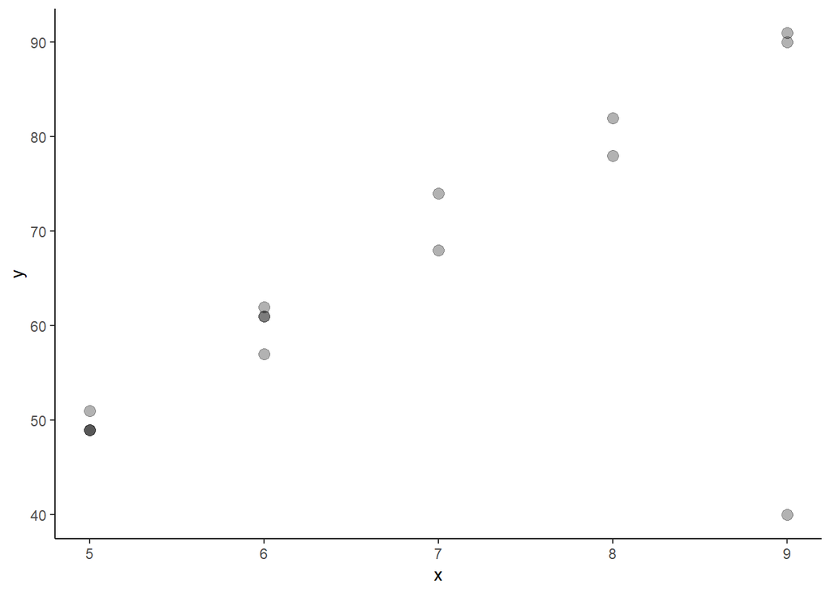

```r
example_data <-
  data_frame(
    x=c(8, 9, 6, 5, 9, 5, 6, 7, 8, 9, 6, 5, 5, 6, 7),
    y=c(82, 91, 61, 49, 40, 49, 57, 74, 78, 90, 61, 49, 51, 62, 68))
example_data %>%
  ggplot() +
  geom_point(aes(x, y), size = 3, alpha=.3) +
  theme_classic()
```

標準化されたマハラノビス距離を見る.

```r
md <- maha_dist(example_data)
```

```r
example_data %>%
  insist_rows(
    maha_dist, within_n_mads(3), dplyr::everything(), error_fun = just_warn)
```

```
## Data frame row reduction 'maha_dist' violates predicate 'within_n_mads(3)' 1 time
##          verb  redux_fn        predicate               column index
## 1 insist_rows maha_dist within_n_mads(3) ~dplyr::everything()     5
##      value
## 1 12.81899
```

| x | y |
| --- | --- |
| 8 | 82 |
| 9 | 91 |
| 6 | 61 |
| 5 | 49 |
| 9 | 40 |
| 5 | 49 |
| 6 | 57 |
| 7 | 74 |
| 8 | 78 |
| 9 | 90 |

[output cut: 5 more lines]

`assert_rows`も`insist_rows`と同様の挙動を示す.

```r
iris %>% num_row_NAs()
```

```
##   [1] 0 0 0 0 0 0 0 0 0 0 0 0 0 0 0 0 0 0 0 0 0 0 0 0 0 0 0 0 0 0 0 0 0 0 0
##  [36] 0 0 0 0 0 0 0 0 0 0 0 0 0 0 0 0 0 0 0 0 0 0 0 0 0 0 0 0 0 0 0 0 0 0 0
##  [71] 0 0 0 0 0 0 0 0 0 0 0 0 0 0 0 0 0 0 0 0 0 0 0 0 0 0 0 0 0 0 0 0 0 0 0
## [106] 0 0 0 0 0 0 0 0 0 0 0 0 0 0 0 0 0 0 0 0 0 0 0 0 0 0 0 0 0 0 0 0 0 0 0
## [141] 0 0 0 0 0 0 0 0 0 0
```

```r
assert_rows(iris, num_row_NAs, within_bounds(0,2), dplyr::everything())
```

| Sepal.Length | Sepal.Width | Petal.Length | Petal.Width | Species |
| --- | --- | --- | --- | --- |
| 5.1 | 3.5 | 1.4 | 0.2 | setosa |
| 4.9 | 3.0 | 1.4 | 0.2 | setosa |
| 4.7 | 3.2 | 1.3 | 0.2 | setosa |
| 4.6 | 3.1 | 1.5 | 0.2 | setosa |
| 5.0 | 3.6 | 1.4 | 0.2 | setosa |
| 5.4 | 3.9 | 1.7 | 0.4 | setosa |
| 4.6 | 3.4 | 1.4 | 0.3 | setosa |
| 5.0 | 3.4 | 1.5 | 0.2 | setosa |
| 4.4 | 2.9 | 1.4 | 0.2 | setosa |
| 4.9 | 3.1 | 1.5 | 0.1 | setosa |

[output cut: 140 more lines]

### success and error functions

実はここまでに紹介した`assert`などの関数では, `success_fun`と`error_fun`がそれぞれ指定されていた.

- success_fun
- success_continue
- success_logical: return TRUE
- error_fun
- error_stop
- error_report
- error_append
- error_logical
- jsut_warn
- warn_report

### combining chains of assertions

通常のassertでは, 最初にエラーが出たところから先の評価が 行われない.

```r
mtcars %>%
  verify(has_all_names("mpg", "vs", "am")) %>%
  verify(nrow(mtcars) > 10) %>%
  verify(mpg > 0) %>%
  insist(within_n_sds(4), mpg) %>%
  assert(in_set(0,1), am, vs) %>%
  group_by(cyl) %>%
  summarise(avg.mpg=mean(mpg))
```

| cyl | avg.mpg |
| --- | --- |
| 4 | 26.66364 |
| 6 | 19.74286 |
| 8 | 15.10000 |

次のようにすれば全てが評価される.

```r
mtcars %>%
  chain_start %>%
  verify(nrow(mtcars) > 10) %>%
  verify(mpg > 0) %>%
  insist(within_n_sds(4), mpg) %>%
  assert(in_set(0,1), am, vs) %>%
  chain_end %>%
  group_by(cyl) %>%
  summarise(avg.mpg=mean(mpg))
```

| cyl | avg.mpg |
| --- | --- |
| 4 | 26.66364 |
| 6 | 19.74286 |
| 8 | 15.10000 |

assert chainは関数にすることも可能.

```r
check_me <- . %>%
  chain_start %>%
  verify(nrow(mtcars) > 10) %>%
  verify(mpg > 0) %>%
  insist(within_n_sds(4), mpg) %>%
  assert(in_set(0,1), am, vs)
  chain_end
```

```
## function (data, success_fun = success_continue, error_fun = error_report)
## {
##     list_of_errors <- attr(data, "assertr_errors")
##     attr(data, "assertr_errors") <- NULL
##     if (is.null(list_of_errors))
##         return(success_fun(data))
##     error_fun(list_of_errors, data = data)
## }
## <bytecode: 0x000000005f6d55d0>
## <environment: namespace:assertr>
```

```r
mtcars %>%
  check_me %>%
  group_by(cyl) %>%
  summarise(avg.mpg=mean(mpg))
```

| cyl | avg.mpg |
| --- | --- |
| 4 | 26.66364 |
| 6 | 19.74286 |
| 8 | 15.10000 |

応用してエラーの場合にはメールを送信するようにする.

```r
library(mailR)

email_me <- function(list_of_errors, data=NULL, ...){
  # we are checking to see if there are any errors that
  # are still attached to the data.frame
  if(!is.null(data) && !is.null(attr(data, "assertr_errors")))
    errors <- append(attr(data, "assertr_errors"), errors)

  num.of.errors <- length(list_of_errors)

  preface <- sprintf("There %s %d error%s:\n",
                     ifelse(num.of.errors==1,"is", "are"),
                     num.of.errors,
                     ifelse(num.of.errors==1,"", "s"))

  # all `assertr_error` S3 objects have `print` and `summary` methods
  # here, we will call `print` on all of the errors since `print`
  # will give us the complete/unabridged error report
  error_string <- capture.output(tmp <- lapply(list_of_errors,
                                               function(x){
                                                 cat("\n- ");
                                                 print(x);
                                                 return();}))
  error_string <- c(preface, error_string)
  error_string <- error_string %>% paste0(collapse="\n")

  send.mail(from="assertr@gmail.com", to="nonsabotage@gmail.com",
            subject="error from assertr", body=error_string,
            smtp = list(host.name="aspmx.l.google.com", port=25),
            authenticate = FALSE, send=TRUE)
  stop("assertr stopped execution", call.=FALSE)
}

mtcars %>%
  chain_start %>%
  verify(nrow(.) > 10) %>%
  insist(within_n_sds(1), mpg) %>%
  # ...
  chain_end(error_fun=email_me)
```

### creating your onwn predicaet generators for insist

```r
within_3_iqrs <- function(a_vector){
  the_median <- median(a_vector)
  the_iqr <- IQR(a_vector)
  within_bounds((the_median-the_iqr*3), (the_median+the_iqr*3))
}
mtcars %>%
  insist(within_3_iqrs, mpg, error_fun=just_warn) %>%
  group_by(cyl) %>%
  summarise(avg.mpg=mean(mpg))
```

| cyl | avg.mpg |
| --- | --- |
| 4 | 26.66364 |
| 6 | 19.74286 |
| 8 | 15.10000 |

```r
within_n_iqrs <- function(n, ...){
  function(a_vector){
    the_median <- median(a_vector)
    the_iqr <- IQR(a_vector)
    within_bounds((the_median-the_iqr*n), (the_median+the_iqr*n), ...)
  }
}
mtcars %>%
  insist(within_n_iqrs(5), mpg) %>%
  group_by(cyl) %>%
  summarise(avg.mpg=mean(mpg))
```

| cyl | avg.mpg |
| --- | --- |
| 4 | 26.66364 |
| 6 | 19.74286 |
| 8 | 15.10000 |